# Final Project Preliminary Report

Luke Sturgeon  
Stat 517  
11/15/18

### Introduction

Spokane Mining and Research Division (SMRD) is interested in how fatigue factors into workplace accidents. Since miners are exposed to a unique environment, these conditions may affect how workers respond to fatigue. Specifically, the team is interested in gleaning information from the narrative fields that may tell us if the accident was related to fatigue. Since mine operators, safety personal, and the miners themselves have a strong incentive not to report on the job fatigue, this will have to be done in a more nuanced way.

I plan to approach this problem with unsupervised learning. Unsupervised learning takes data and tries to see how the data groups itself. It does not need to have the data specified (i.e. have a ?Fatigue? column with 0, 1 whether it does or doesn?t have to do with fatigue), it?s simply looking for trends. Vectorizing the narrative fields and removing any unnecessary words (either they are filler words, or they explain too little variance, decided through PCA [Principle Component Analysis]) will create a second data set. This dataset will be clustered through various methods, and the method that provides the clearest groupings will be used going forward with the analysis. Once these groups have been created, term frequency counts and other metrics can be used to see why each observation is like its neighbor. Any groups that appear to have fatigue as a possible culprit will have all the observations in that group separated from the AII reports for further analysis with the other 56 variables in the dataset. These analyses will include supervised and association methods, to see if robust predictive models can be made and what words are likely to be associated with fatigue related injuries, respectively.

### Data and Packages

```r
install.packages("mclust",repos="https://ftp.osuosl.org/pub/cran/")
install.packages("cluster",repos="https://ftp.osuosl.org/pub/cran/")
install.packages("ggplot2",repos="https://ftp.osuosl.org/pub/cran/")
install.packages("factoextra",repos="https://ftp.osuosl.org/pub/cran/")
install.packages("wordcloud",repos="https://ftp.osuosl.org/pub/cran/")
install.packages("FactoMineR",repos="https://ftp.osuosl.org/pub/cran/")
install.packages("tidytext",repos="https://ftp.osuosl.org/pub/cran/")
install.packages("SnowballC",repos="https://ftp.osuosl.org/pub/cran/")
install.packages("caret",repos="https://ftp.osuosl.org/pub/cran/")
install.packages("seriation",repos="https://ftp.osuosl.org/pub/cran/")
install.packages("arules",repos="https://ftp.osuosl.org/pub/cran/")
install.packages("arulesViz",repos="https://ftp.osuosl.org/pub/cran/")
install.packages("tm",repos="https://ftp.osuosl.org/pub/cran/")
library(arules)
library(arulesViz)
library(seriation)
library(tidytext)
library(caret)
library(wordcloud)
library(SnowballC)
library(FactoMineR)
library(mclust)
library(cluster)
library(ggplot2)
library(tm)
library(factoextra)
accidents <- read.csv("https://www.dropbox.com/s/ayfbrrlo1zujga9/Accidents.txt?dl=1", header=T, sep="|")
colnames(accidents) <- tolower(colnames(accidents))
```

### Vectorizing the Narrative Field

```r
narratives <- as.matrix(accidents$narrative)
row.names(narratives) <- accidents$document_no
docs <- Corpus(VectorSource(accidents$narrative))
docs <- tm_map(docs, removePunctuation)
docs <- tm_map(docs,content_transformer(tolower))
docs <- tm_map(docs, removeNumbers)
docs <- tm_map(docs, removeWords, stopwords("english"))
docs <- tm_map(docs, stripWhitespace)
docs <- tm_map(docs,stemDocument)
dtm <- DocumentTermMatrix(docs)
dim(dtm)
```

```
## [1] 115385  91865
```

```r
dtm <- removeSparseTerms(dtm, 0.98)
dtm
```

```
## <<DocumentTermMatrix (documents: 115385, terms: 335)>>
## Non-/sparse entries: 1784551/36869424
## Sparsity           : 95%
## Maximal term length: 26
## Weighting          : term frequency (tf)
```

I’d like to see what words are the most common to get a better sense of the matrix.

```r
freq <- colSums(as.matrix(dtm))
ord <- order(freq,decreasing=TRUE)
print(freq[head(ord)])
```

```
##    valu foundno employe    work    fall    oper
##  386685  214764  104154   77372   73588   63446
```

```r
freq[tail(ord)]
```

```
##  backward     carri experienc    someth      just    assist
##      2871      2850      2849      2837      2797      2749
```

### PCA

To make the clustering and association packages run quicker later in this analysis, I’ll reduce the data even further. As long as I can explain an adequate amount of variance, I should be alright reducing the dataset even further.

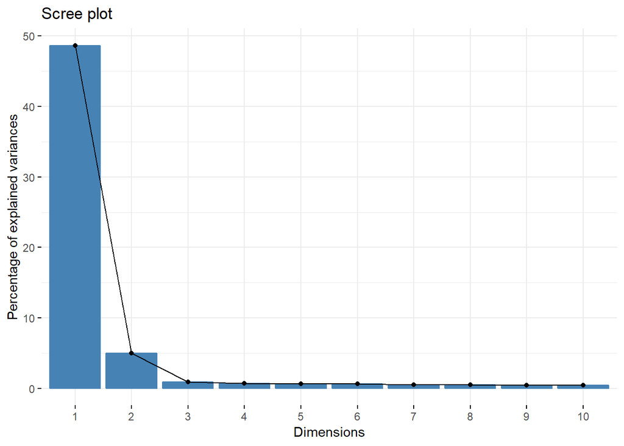

```r
dtm.m <- as.matrix(dtm)
dtm.m.prcomp <- prcomp(dtm.m, scale = T)
fviz_eig(dtm.m.prcomp)
```

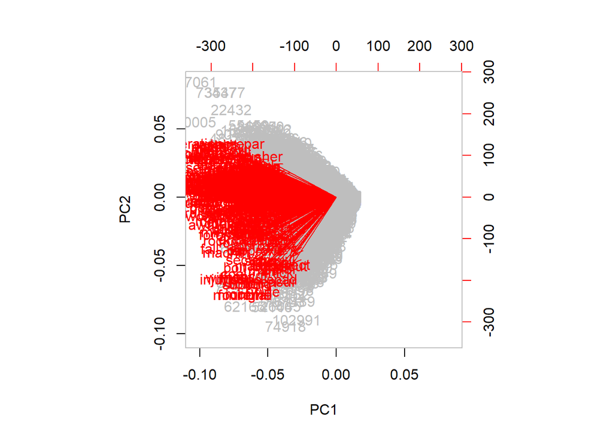

```r
biplot(dtm.m.prcomp, col=c("grey","red"))
```

```r
get_eig(dtm.m.prcomp)[188:208,]
```

```
##         eigenvalue variance.percent cumulative.variance.percent
## Dim.188  0.3771538       0.11258322                    92.95663
## Dim.189  0.3738474       0.11159624                    93.06823
## Dim.190  0.3724670       0.11118418                    93.17941
## Dim.191  0.3705104       0.11060012                    93.29001
## Dim.192  0.3682724       0.10993207                    93.39994
## Dim.193  0.3620803       0.10808368                    93.50803
## Dim.194  0.3582670       0.10694538                    93.61497
## Dim.195  0.3569087       0.10653991                    93.72151
## Dim.196  0.3545504       0.10583594                    93.82735
## Dim.197  0.3532044       0.10543416                    93.93278
## Dim.198  0.3506064       0.10465864                    94.03744
## Dim.199  0.3445084       0.10283834                    94.14028
## Dim.200  0.3427111       0.10230181                    94.24258
## Dim.201  0.3366688       0.10049815                    94.34308
## Dim.202  0.3355417       0.10016170                    94.44324
## Dim.203  0.3318645       0.09906404                    94.54231
## Dim.204  0.3295616       0.09837659                    94.64068
## Dim.205  0.3278091       0.09785347                    94.73854
## Dim.206  0.3244817       0.09686021                    94.83540
## Dim.207  0.3207531       0.09574720                    94.93114
## Dim.208  0.3174972       0.09477527                    95.02592
```

```r
pca.frame <- (dtm.m.prcomp$x[,1:28])
```

We see that 95% of the variance can be explained with the first 208 dimensions of our PCA.

### Clustering

Now that we have our reduced dataframe, we can start analysing which narrative fields should be grouped together. We start with model based clustering.When run with the 208 dimensions that 95% variability explanation gives us, the clustering takes too long (more than overnight, at least I stopped the procedure in the morning). Reducining the dimensions down to 50 is still taking hours to finish the model based clustering. Will have to research better ways to narrow the DTM by number of observations. Perhaps going through and eliminating all fields that were caused by mechanical failure rather than human error before uploading dataset to R and starting the pre-processing and analysis

We move on to hierarchical clustering, starting by finding the best distance to use with this data. Since it’s all words, my guess is cosine should work the best. If not, need to check the dtm to make sure it’s doing what it’s supposed to before believing the results. Cosine does not come standard with “dist” function, have to find one that does give cosine distance.

```r
#e <- dist(pca.frame, method="euclidian")
#max <- dist(pca.frame, method="maximum")
#man <- dist(pca.frame, method="manhattan")
#can <- dist(pca.frame, method="canberra")
#bin <- dist(pca.frame, method="binary")
#min <- dist(pca.frame, method="minkowski")
#hcluster.es <- hclust(e, method="single")
#hcluster.ea <- hclust(e, method="average")
#hcluster.em <- hclust(e, method="median")
#hcluster.ec <- hclust(e, method="centroid")
#hcluster.ew <- hclust(e, method="ward.D2")
#hcluster.maxs <- hclust(max, method="single")
#hcluster.maxa <- hclust(max, method="average")
#hcluster.maxm <- hclust(max, method="median")
#hcluster.maxc <- hclust(max, method="centroid")
#hcluster.maxw <- hclust(max, method="ward.D2")
#hcluster.mans <- hclust(man, method="single")
#hcluster.mana <- hclust(man, method="average")
#hcluster.manm <- hclust(man, method="median")
#hcluster.manc <- hclust(man, method="centroid")
#hcluster.manw <- hclust(man, method="ward.D2")
#hcluster.cans <- hclust(can, method="single")
#hcluster.cana <- hclust(can, method="average")
#hcluster.canm <- hclust(can, method="median")
#hcluster.canc <- hclust(can, method="centroid")
#hcluster.canw <- hclust(can, method="ward.D2")
#hcluster.bins <- hclust(bin, method="single")
#hcluster.bina <- hclust(bin, method="average")
#hcluster.binm <- hclust(bin, method="median")
#hcluster.binc <- hclust(bin, method="centroid")
#hcluster.binw <- hclust(bin, method="ward.D2")
#hcluster.mins <- hclust(min, method="single")
#hcluster.mina <- hclust(min, method="average")
#hcluster.minm <- hclust(min, method="median")
#hcluster.minc <- hclust(min, method="centroid")
#hcluster.minw <- hclust(min, method="ward.D2")
#plot(hcluster.es)
```

```r
#plot(hcluster.manc)
```

```r
#plot(hcluster.bins)
```

The dist functions can’t handle the size of the pca.frame object, apparently it’s 49.6 Gb. Have to reduces the number of observations before input into the system.

Trying k means clustering next

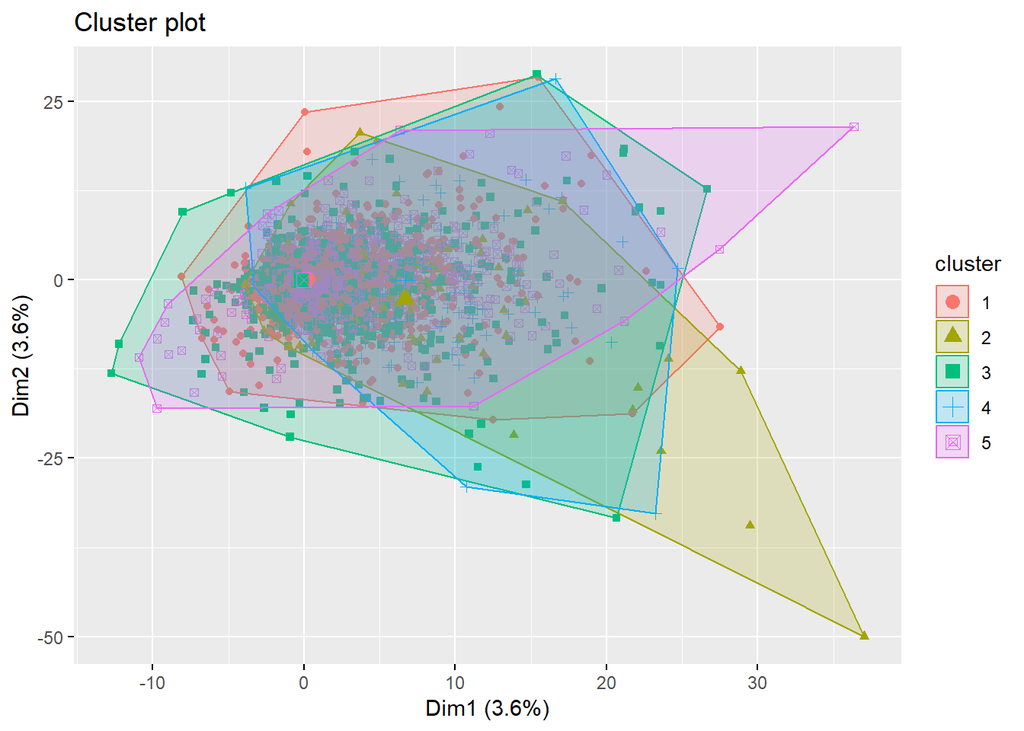

```r
k1 <- kmeans(pca.frame[,-c(1:2)], 5, nstart =10)
fviz_cluster(k1,pca.frame, geom = "point")
```

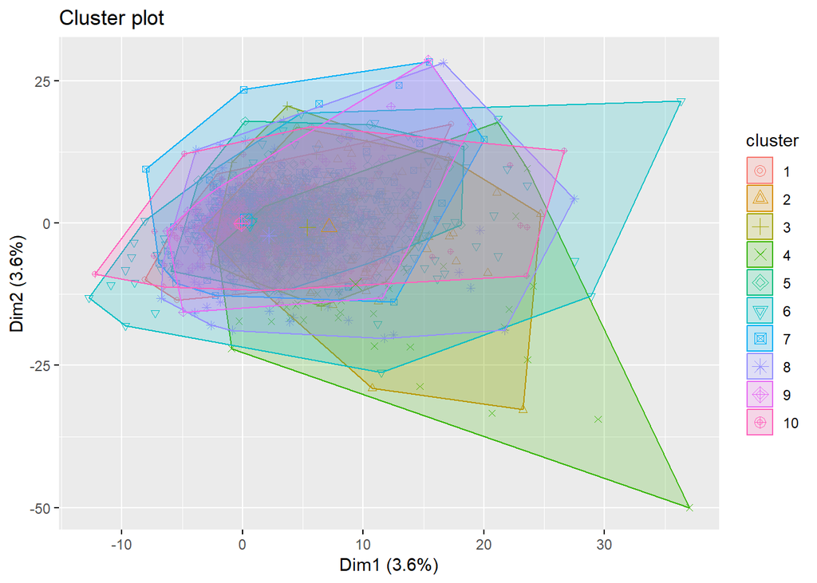

```r
k2 <- kmeans(pca.frame[,-c(1:2)], 10, nstart =10)
fviz_cluster(k2,pca.frame, geom = "point")
```

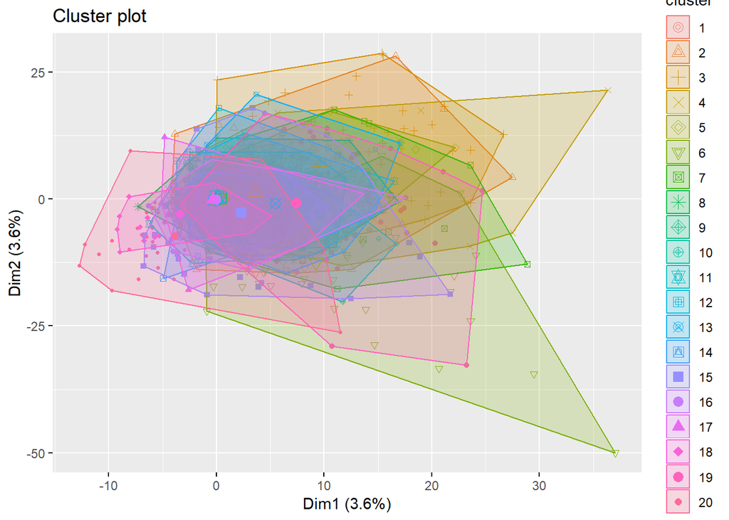

```r
k3 <- kmeans(pca.frame[,-c(1:2)], 20, nstart =10)
fviz_cluster(k3,pca.frame, geom = "point")
```

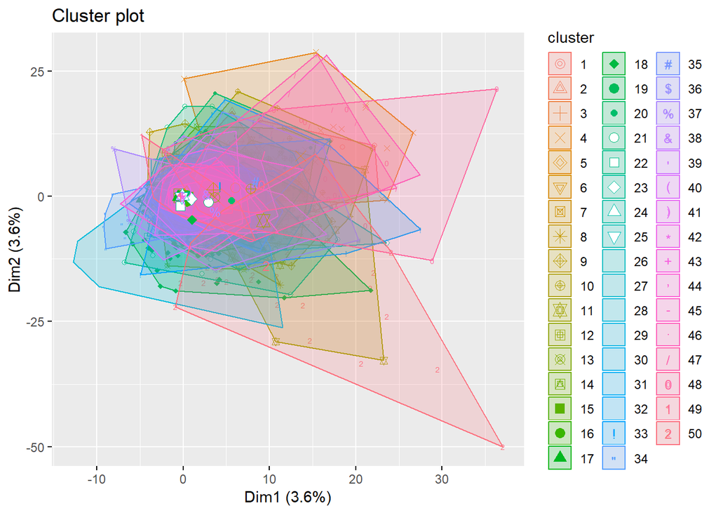

```r
k4 <- kmeans(pca.frame[,-c(1:2)], 50, nstart =10)
fviz_cluster(k4,pca.frame, geom = "point")
```

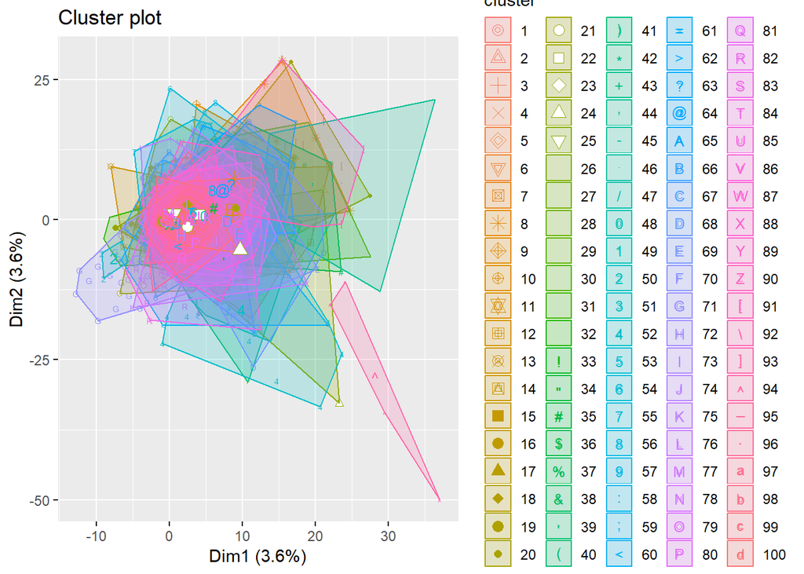

```r
k5 <- kmeans(pca.frame[,-c(1:2)], 100, nstart =10)
fviz_cluster(k5,pca.frame, geom = "point")
```

### To Dos

Once appropriately clustered, feature selection is up next. I’m planning on using the most frequent words used in each cluster as a good indication of what each cluster is saying/why these narrative fields are clustered. RobotAnalyst has a different method of feature selection that I want to look into. I think a more nuanced approach to feature selection is required for this project since there’s an incentive not to come out and say you were tired and that’s what caused the accident.

Once clusters are selected as relating to miner fatigue, those narrative fields that compose those clusters will be filtered from the larger dataset. With those in hand, exploratory data analysis and any further statistical analyses required to predict what conditions may lead to an accident caused by fatigue will be done.